# lecture-12-sample-size-statistical-theory-ii

## M303 Sample Size and Statistical Theory II

FALL 2026 · LECTURE 12

M303

Sample Size and Statistical Theory II

Turn sampling uncertainty into confidence intervals and defensible sample-size calculations.

## Where we are

01**Sample design**

Define the population, sampling frame, and sampling procedure.

→

02**Statistical foundations**

Distinguish population parameters from sample statistics.

→

03**Inference and precision**

Use confidence intervals and sampling error to choose a defensible sample size.

## Learning Objectives

01**Infer**

Use a sample statistic to reason about an unknown population parameter.

02**Quantify uncertainty**

Construct and interpret confidence intervals for a population mean.

03**Plan**

Determine the sample size needed for a desired confidence level and sampling error.

04**Communicate**

Use graphical representations to make sample evidence clear.

## Previous-class review

01

A larger sample is automatically more representative than a smaller sample.

02

A population parameter describes the full population; a sample statistic describes the observed sample.

03

Greater population variability generally requires a larger sample for the same precision.

## How do we infer the population mean μ from the sample mean x̄?

**Remember: x̄ ≠ μ.**

We use the sample mean x̄ to learn about the population mean μ.

We usually cannot know μ exactly, but we can construct an interval around x̄ that has a high confidence level—such as 90% or 95%—of capturing μ.

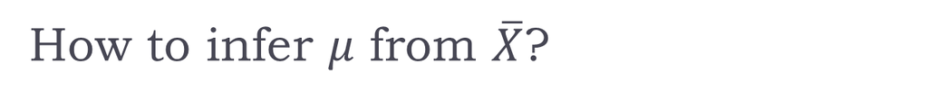

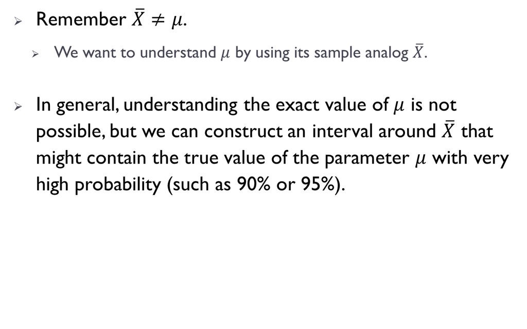

## How do we construct confidence intervals for μ?

**Confidence interval**

CI for μ = x̄ ± E = (x̄ − E, x̄ + E)

**Sampling error**

E = zσ / √n

Use z = 2 for 95% confidence and z = 5/3 for 90% confidence. If σ is unknown, use the sample standard deviation S.

**Example:** x̄ = 0, S = 1.41, and n = 9. What are the 95% and 90% confidence intervals for μ?

## How do we determine sample size statistically?

**Start with sampling error**

E = zσ / √n

**Solve for sample size**

n = z²σ² / E²

If σ is unknown, use S from a pilot or test sample.

**Example**

Desired sampling error E = 0.30 and estimated variance S² = 2.

## Graphical Representations

In addition to sample statistics, graphical charts can be used for preliminary data analysis such as

Bar charts

Pie charts

Line charts

## Example: Graphical Representations

In choosing a computer, which factor is more important to you? (N = 300)

Design factor · Performance · Both equally

| Preference | College students | College graduates | Total |
| --- | --- | --- | --- |
| Design factor | 100 | 44 | 144 |
| Performance | 60 | 86 | 146 |
| Both equally | 5 | 5 | 10 |
| Total | 165 | 135 | 300 |

## Example: Grouped Bar and Line Charts

### Grouped bar chart

College studentsCollege graduatesTotal

**Design factor**

**Performance**

**Both equally**

### Students vs. graduates

[figure not shown]

College studentsCollege graduates

Use the instructor-designed Web Tools during the in-class illustration; instructions and required data files will be posted on Canvas.[Open M303 Web Tools ↗](https://koraycosguner.github.io/tools.html)

## Example: Pie Charts by Group

### College students · n = 165

165

- **100** Design · 60.6%
- **60** Performance · 36.4%
- **5** Both · 3.0%

### College graduates · n = 135

135

- **44** Design · 32.6%
- **86** Performance · 63.7%
- **5** Both · 3.7%

### Total · N = 300

300

- **144** Design · 48.0%
- **146** Performance · 48.7%
- **10** Both · 3.3%

## Practice question 1

Practice Question 1

A population of 25,000 design engineers was asked: “How important is it that the machine be capable of working with both hard and soft metals?”

What are the population mean, variance, and standard deviation?

| Scale | Description | Frequency | Percentage |
| --- | --- | --- | --- |
| 5 | Extremely important | 5,000 | 20 |
| 4 | Important | 8,000 | 32 |
| 3 | Desirable | 6,000 | 24 |
| 2 | Only a small plus | 2,000 | 8 |
| 1 | Of no consequence | 4,000 | 16 |
| Total |  | 25,000 | 100 |

| Scale | Description | Frequency | Percentage |
| --- | --- | --- | --- |
| 5 | Extremely important | 5,000 | 20 |
| 4 | Important | 8,000 | 32 |
| 3 | Desirable | 6,000 | 24 |
| 2 | Only a small plus | 2,000 | 8 |
| 1 | Of no consequence | 4,000 | 16 |
| Total |  | 25,000 | 100 |

## Practice Question 2

Suppose we want to understand fast-food consumption among college students.

We ask:

“On average, how often do you eat at—or take out from—fast-food restaurants in a month?”

a. What are the sample mean, variance, and standard deviation?

b. What is the 95% confidence interval estimate for the population mean?

c. At 95% confidence, if the desired margin of error is 1.1, what sample size is required?

| Respondent | Fast-food visits |
| --- | --- |
| 1 | 5 |
| 2 | 6 |
| 3 | 7 |
| 4 | 3 |
| 5 | 5 |
| 6 | 4 |

| Respondent | Fast-food visits |
| --- | --- |
| 1 | 5 |
| 2 | 6 |
| 3 | 7 |
| 4 | 3 |
| 5 | 5 |
| 6 | 4 |

## To sum up

Factors determining sample size

How to determine the sample size by ad hoc techniques

Parameters and statistics

How to calculate parameters and statistics of central tendency and dispersion

Calculating confidence intervals for the population mean

Determining the sample size with statistical techniques

Basic graphical illustrations of data such as bar, pie and line charts

## Next class

COMING UP

Data Editing, Coding, and Descriptive Analysis

**Why it matters**Move from collected responses to analysis-ready data and useful summaries.

**Current milestones**Check Canvas for practice-assignment deadlines, term-project reminders, and review information.